# HW6

Group 8

2 July 2024

Group:

Lisa Bensousan - 346462534 - lisa.bensoussan@mail.huji.ac.il  
Dan Levy - 346453202 - dan.levy5@mail.huji.ac.il  
Emmanuelle Fareau - 342687233 - emmanuel.fareau@mail.huji.ac.il

### Libraries used

```r
library(dplyr)
library(ggplot2)
library(splines)
library(data.table)
library(caret)
```

### Paths and Data

```r
# reads_data <- "/Users/lisabensoussan/Desktop/lab6/TCGA-13-0723-01A_lib1_all_chr1.forward"
# chr1_reads = fread(reads_data)
# colnames(chr1_reads) = c("Chrom","Loc","FragLen")
# head(chr1_reads)
# load("/Users/lisabensoussan/Desktop/lab6/chr1_str_30M_50M.rda")


load("C:/Users/Emmanuelle Fareau/Downloads/chr1_str_30M_50M.rda")

reads_data <- "/Users/Emmanuelle Fareau/Documents/Cours 2023-2024    (annee 4)/Maabada/TCGA-13-0723-01A_lib1_all_chr1.forward"
chr1_reads = fread(reads_data)
colnames(chr1_reads) = c("Chrom","Loc","FragLen")
head(chr1_reads)
```

```
##    Chrom   Loc FragLen
##    <int> <int>   <int>
## 1:     1    28     153
## 2:     1    35     184
## 3:     1    35     177
## 4:     1    36     186
## 5:     1    37       0
## 6:     1    37     242
```

```r
# reads_data <- "/Users/Emmanuelle Fareau/Documents/Cours 2023-2024    (annee 4)/Maabada/TCGA-13-0723-01A_lib1_all_chr1.forward"
# chr1_reads = fread(reads_data)
# colnames(chr1_reads) = c("Chrom","Loc","FragLen")
# head(chr1_reads)
#
#
data <- chr1_reads
```

## Introduction

In this work, we would like to delve deeper into the subject of copy number. For this, we will assume a random variable (Y) which follows a Poisson distribution of lambda expectation. Using this model and several mathematical calculations we will try to estimate the number of copies and check the quality of the estimator.

## Part 1

We have a model of the following form :

$$Y_{i} \sim Poisson
(\lambda_{i})$$

$$\lambda_{i} = a_{i} \times f(gc_{i})
\times \eta_{i}$$

For this model, we want to estimate the number of copies ($\hat{a}$).

```r
sequence <- chr1_str_30M_50M
sequence <- strsplit(sequence, "")
sequence <- sequence[[1]]

frag <- as.numeric(chr1_reads$FragLen)

segment_length <- 10000
num_segments <- length(sequence)/10000

segments <- split(sequence, rep(1:num_segments, each = segment_length, length.out = length(sequence)))


calculate_gc_content <- function(seq) {
  gc_count <- sum(seq == "G" | seq == "C")
  return(gc_count)
}

gc_contents <- sapply(segments, calculate_gc_content)
head(gc_contents)
```

```
##    1    2    3    4    5    6
## 4966 3604 4075 5110 4911 4993
```

Then we will calculate the number of fragments per segment :

```r
count_fragment_starts <- function(data, chrom_number, start_range, end_range) {
  relevant_data <- data[Chrom == chrom_number & Loc >= start_range & Loc <= end_range,]
  start_counts <- integer(end_range - start_range + 1)
  names(start_counts) <- as.character(start_range:end_range)

  starts <- table(relevant_data$Loc)

  start_positions <- as.character(names(starts))
  start_counts[start_positions] <- as.integer(starts)

  return(start_counts)
}

fragment_counts <- count_fragment_starts(chr1_reads, 1, 0, 20000000)



sum_frag <- numeric(length = length(fragment_counts) / 10000)


for (i in seq(1, length(fragment_counts), by = 10000)) {
  group_index <- (i - 1) / 10000
  sum_frag[group_index] <- sum(fragment_counts[i:(i+9999)])
}


head(sum_frag)
```

```
## [1] 36 22 17 58 42 53
```

For convenience, we will create a data which contains the two vectors that we want to calculate. That is to say the number of GCs and the number of fragments for each fragment of the chromosomes.

Finally, we will apply a spline regression on our model, with our GC count as an explanatory variable and our number of fragmentations as a variable to predict.

```r
data <- data.frame(gc_count = gc_contents, fragment = sum_frag)

knots <- quantile(data$gc_count, probs = c(0.25, 0.5, 0.75))

model <- lm(fragment ~ ns(gc_count, knots = knots), data = data)

print(summary(model))
```

```
##
## Call:
## lm(formula = fragment ~ ns(gc_count, knots = knots), data = data)
##
## Residuals:
##     Min      1Q  Median      3Q     Max
## -716.73  -55.45   60.91  127.34 1750.62
##
## Coefficients:
##                              Estimate Std. Error t value Pr(>|t|)
## (Intercept)                    766.11      66.87  11.457   <2e-16 ***
## ns(gc_count, knots = knots)1   -93.86      62.15  -1.510   0.1311
## ns(gc_count, knots = knots)2  -108.27      47.76  -2.267   0.0235 *
## ns(gc_count, knots = knots)3  -141.93     146.61  -0.968   0.3331
## ns(gc_count, knots = knots)4   -22.50      50.59  -0.445   0.6566
## ---
## Signif. codes:  0 '***' 0.001 '**' 0.01 '*' 0.05 '.' 0.1 ' ' 1
##
## Residual standard error: 258 on 1994 degrees of freedom
##   (1 observation effacée parce que manquante)
## Multiple R-squared:  0.007196,   Adjusted R-squared:  0.005204
## F-statistic: 3.613 on 4 and 1994 DF,  p-value: 0.006101
```

Thanks to all the steps that we have just carried out, we will now be able to create a function to estimate the number of copies per cell.

This function receives the number of GCs, the number of fragments and the spline regression calculated previously and calculates the estimated number of copies thanks to the following mathematical development:

$$\lambda_{i} = a_{i} \times f(gc_{i})
\times \eta_{i}$$

$$E[Y_{i}] = \lambda_{i}$$

$$E[Y_{i}] =a_{i} \times f(gc_{i}) \times
\eta_{i}$$

$$a_{i} = \frac{E[Y_{i}]}{f(gc_{i})}
\times \frac{1}{\eta_{i}} \simeq \frac{E[Y_{i}]}{f(gc_{i})}$$

$$\hat{a}_{i} =
\frac{Y_{i}}{\hat{f}(gc_{i})}$$

```r
estimate_copy_number <- function(Y, GC, f) {
  f_gc_hat <- predict(model, newdata = data.frame(gc_count = GC))
  a_hat <- Y / f_gc_hat
  return(a_hat)
}


Y <- data$fragment
GC <- data$gc_count


estimated_copy_numbers <- estimate_copy_number(Y, GC, model)
head(estimated_copy_numbers)
```

```
##          1          2          3          4          5          6
## 0.05512763 0.03011074 0.02437794 0.08867777 0.06425227 0.08117233
```

```r
copy_numbers <- list(estimated_copy_numbers)
length(copy_numbers)
```

```
## [1] 1
```

Thanks to this function, we obtained a vector with the estimated number of copies for each chromosome segment. We then transform this into a list of length 1 using the `list` function.

## Part 2

Here we choose the first 1000 intervals and use our function to found the estimate copy number for all intervals.

```r
Y_2 <- data$fragment[1:1000]
GC_2 <- data$gc_count[1:1000]


estimated_copy_numbers_2 <- estimate_copy_number(Y_2, GC_2, model)
head(estimated_copy_numbers_2)
```

```
##          1          2          3          4          5          6
## 0.05512763 0.03011074 0.02437794 0.08867777 0.06425227 0.08117233
```

### a :

We realize a plot which shows us the marginal distribution of copy number estimates. Then we plot the distribution of copy number estimates along the genome.

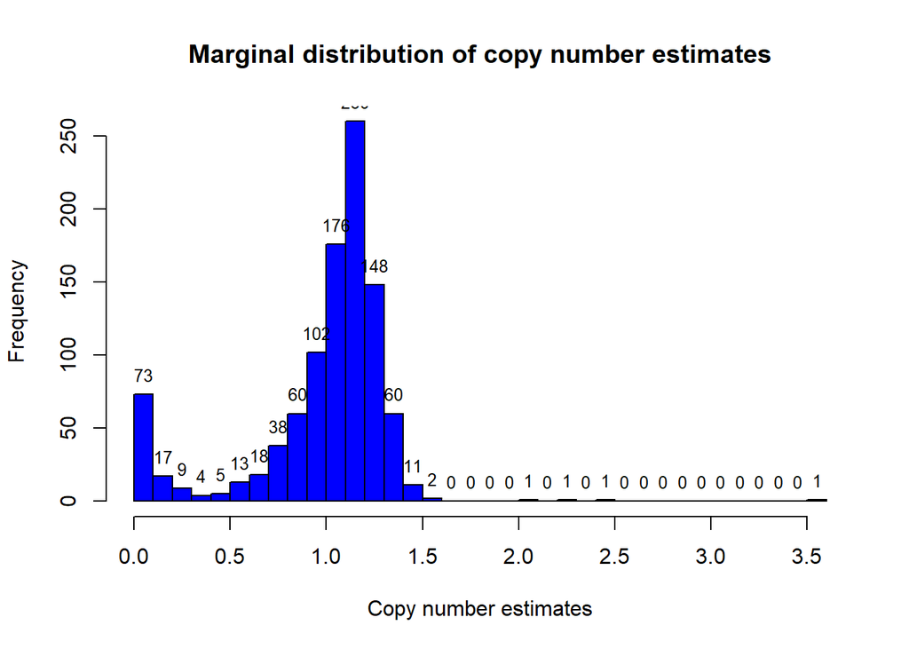

```r
hist_obj<- hist(estimated_copy_numbers_2, breaks = 30, main = "Marginal distribution of copy number estimates",
     xlab = "Copy number estimates", col = "blue", border = "black")
text(x = hist_obj$mids, y = hist_obj$counts, labels = hist_obj$counts, pos = 3, cex = 0.8, col = "black")
```

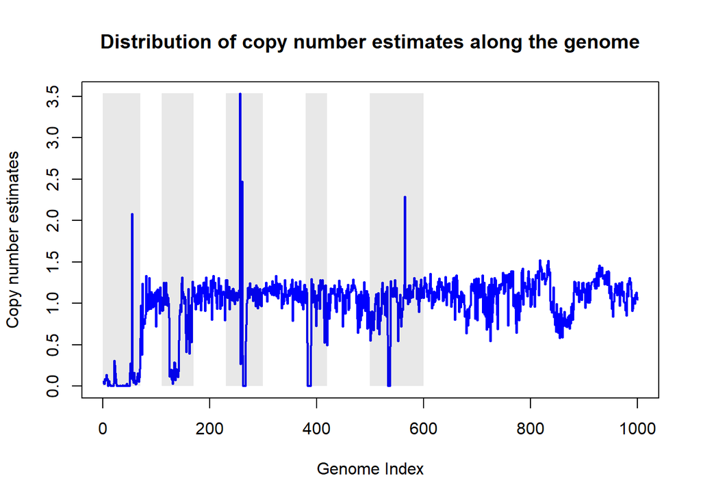

```r
plot(estimated_copy_numbers_2, type = "l", main = "Distribution of copy number estimates along the genome",
     xlab = "Genome Index", ylab = "Copy number estimates", col = "blue", lwd = 2)



rect(0, min(estimated_copy_numbers_2), 70, max(estimated_copy_numbers_2), col = rgb(0.1, 0.1, 0.1, 0.1), border = NA)
rect(110, min(estimated_copy_numbers_2), 170, max(estimated_copy_numbers_2), col = rgb(0.1, 0.1, 0.1, 0.1), border = NA)
rect(230, min(estimated_copy_numbers_2), 300, max(estimated_copy_numbers_2), col = rgb(0.1, 0.1, 0.1, 0.1), border = NA)
rect(380, min(estimated_copy_numbers_2), 420, max(estimated_copy_numbers_2), col = rgb(0.1, 0.1, 0.1, 0.1), border = NA)
rect(500, min(estimated_copy_numbers_2), 600, max(estimated_copy_numbers_2), col = rgb(0.1, 0.1, 0.1, 0.1), border = NA)
```

### b :

We calculate the differences between 1 and the estimated copies number and we want to analyse them .

```r
data$estimated_copy_numbers_2 <- estimated_copy_numbers_2
data$difference <- abs(1-data$estimated_copy_numbers_2)

summary(data$difference)
```

```
##      Min.   1st Qu.    Median      Mean   3rd Qu.      Max.
## 0.0001156 0.0913258 0.1653867 0.2500920 0.2761940 2.5328904
```

```r
lower_bound <- 0.8
upper_bound <- 1.2

close_to_one <- sum(estimated_copy_numbers_2 >= lower_bound & estimated_copy_numbers_2 <= upper_bound)
proportion_close_to_one <- close_to_one / length(estimated_copy_numbers_2)

print(proportion_close_to_one)
```

```
## [1] 0.598
```

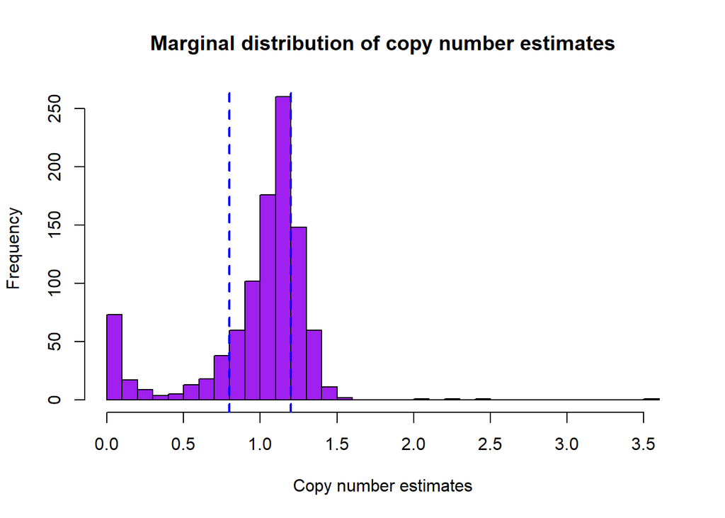

```r
hist_obj<- hist(estimated_copy_numbers_2, breaks = 30, main = "Marginal distribution of copy number estimates",
     xlab = "Copy number estimates", col = "purple", border = "black")
abline(v = c(0.8, 1.2), col = "blue", lwd = 2, lty = 2)
```

We saw that practically 60% of estimates copy numbers are close to 1 by maximum 0.2 distance.

```r
sd_diff <- sd(data$difference)
print(paste("Standard deviation of differences :", sd_diff))
```

```
## [1] "Standard deviation of differences : 0.270969574471721"
```

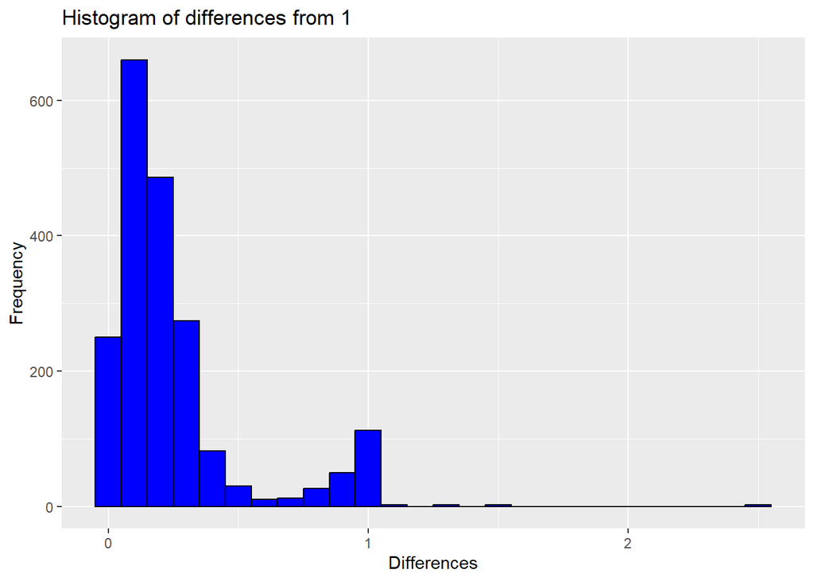

```r
diff_data <- data.frame(Index = 1:length(data$difference), Differences = data$difference)


hist_plot <- ggplot(diff_data, aes(x = Differences)) +
  geom_histogram(binwidth = 0.1, fill = "blue", color = "black") +
  ggtitle("Histogram of differences from 1") +
  xlab("Differences") +
  ylab("Frequency")


box_plot <- ggplot(diff_data, aes(y = Differences)) +
  geom_boxplot(fill = "orange", color = "black") +
  ggtitle("Boxplot of differences from 1") +
  ylab("Differences") +
  coord_cartesian(xlim = c(-1.5, 1.5))


density_plot <- ggplot(diff_data, aes(x = Differences)) +
  geom_density(fill = "green", alpha = 0.5) +
  ggtitle("Density of differences relative to 1") +
  xlab("Differences") +
  ylab("Density")


scatter_plot <- ggplot(diff_data, aes(x = Index, y = Differences)) +
  geom_point(color = "red") +
  ggtitle("Scatter plot of differences along the index") +
  xlab("Genome Index") +
  ylab("Differences")


print(hist_plot)
```

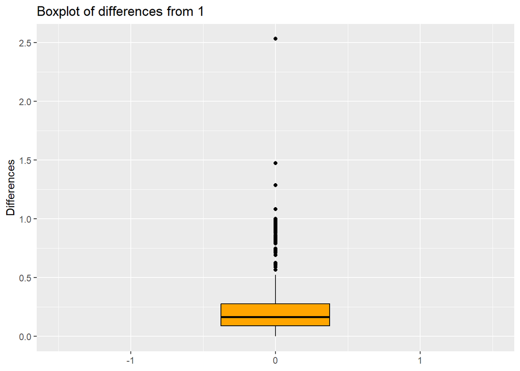

```r
print(box_plot)
```

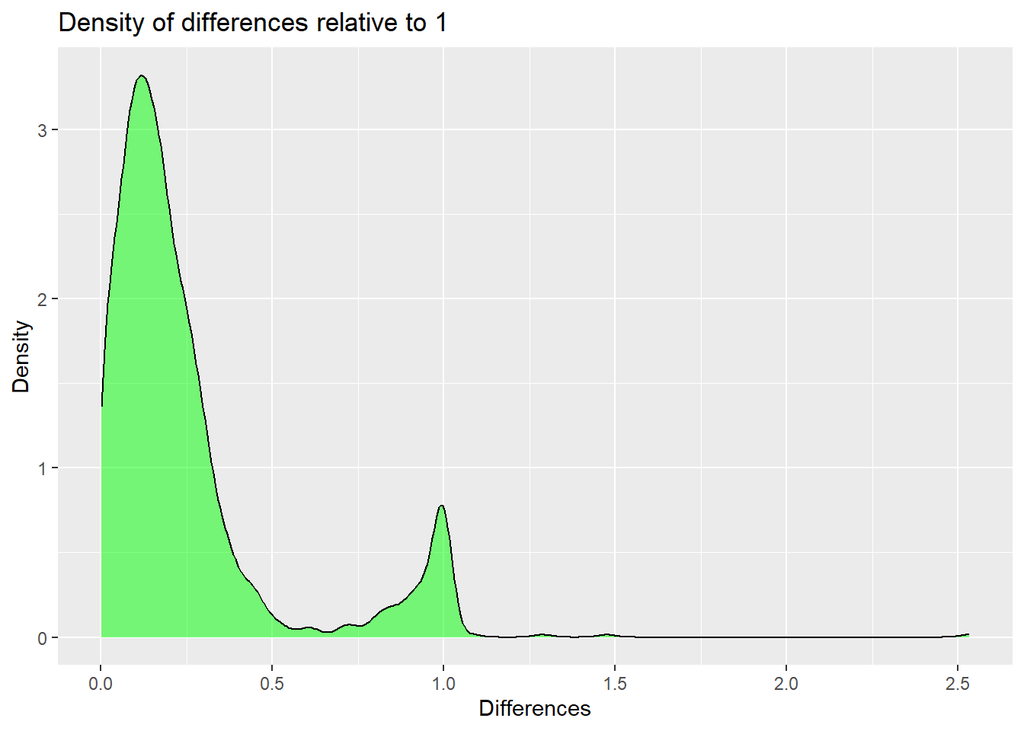

```r
print(density_plot)
```

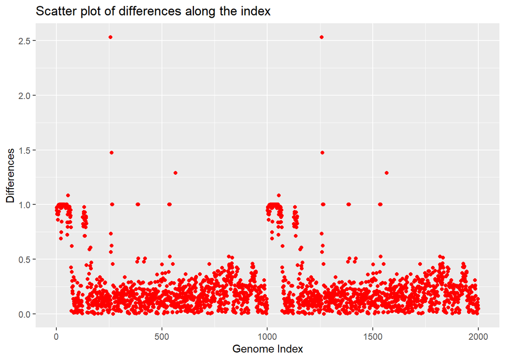

```r
print(scatter_plot)
```

We can see that the majority of differences are very small (thanks to the boxplot or the histogram), which means that the estimates of the number of copies are close to 1 which is optimal.

## Part 3

Here, we have created a function to associate each of our estimate of the number of copies with the real one which is closest. This way we can compare whether our estimates are close to our true copy number values.

```r
data$categorized_copy_number <- with(data, ifelse(data$estimated_copy_numbers_2 < 0.75, 0.5,
                                        ifelse(data$estimated_copy_numbers_2 < 1.25, 1,
                                        ifelse(data$estimated_copy_numbers_2 < 1.75, 1.5, 2))))



data$true_difference <- abs(data$categorized_copy_number - data$estimated_copy_numbers_2)

stats <- summary(data$true_difference)
print(stats)
```

```
##      Min.   1st Qu.    Median      Mean   3rd Qu.      Max.
## 0.0001156 0.0824704 0.1472651 0.1642246 0.2112313 1.5328904
```

```r
sd_diff <- sd(data$true_difference, na.rm = TRUE)
print(paste("Standard deviation of differences :", sd_diff))
```

```
## [1] "Standard deviation of differences : 0.123696988405097"
```

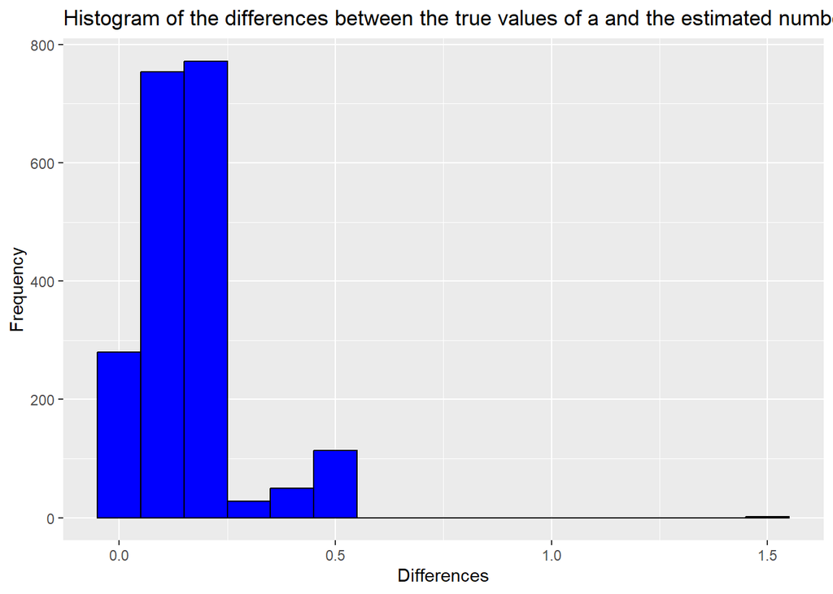

```r
hist_plot <- ggplot(data, aes(x = true_difference)) +
  geom_histogram(binwidth = 0.1, fill = "blue", color = "black") +
  ggtitle("Histogram of the differences between the true values of a and the estimated number of copies (a^)") +
  xlab("Differences") +
  ylab("Frequency")


box_plot <- ggplot(data, aes(y = true_difference)) +
  geom_boxplot(fill = "orange", color = "black") +
  ggtitle("Boxplot of the differences between the true values of a and the estimated values of a") +
  ylab("Differences")


print(hist_plot)
```

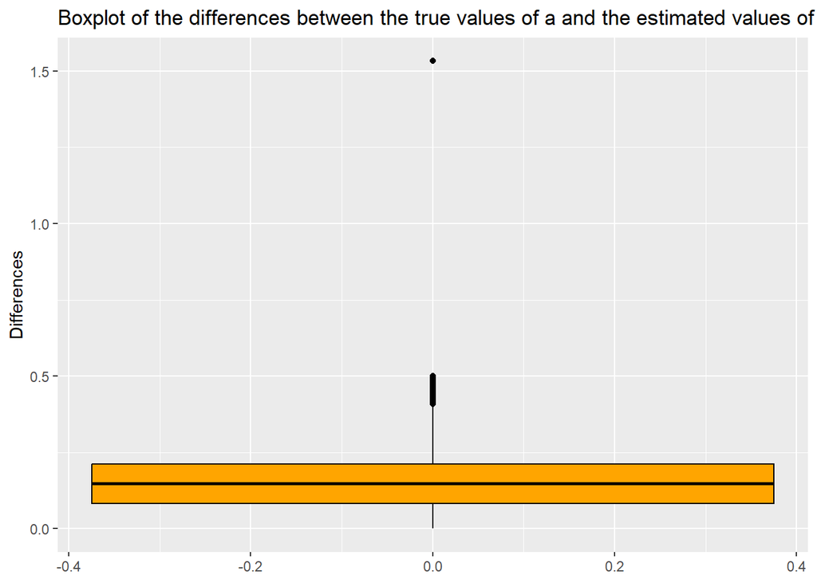

```r
print(box_plot)
```

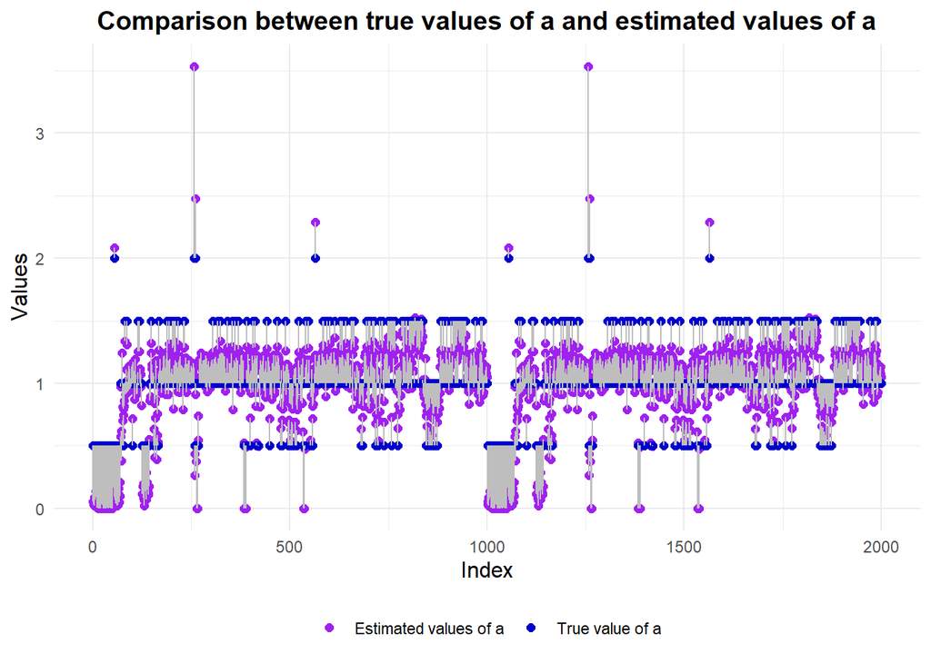

```r
plot <- ggplot(data) +
  geom_point(aes(x = 1:nrow(data), y = estimated_copy_numbers_2, color = "Estimated values of a"), size = 2) +
  geom_point(aes(x = 1:nrow(data), y = categorized_copy_number, color = "True value of a"), size = 2) +
  geom_segment(aes(x = 1:nrow(data), xend = 1:nrow(data),
                   y = estimated_copy_numbers_2, yend = categorized_copy_number), color = "grey") +
  scale_color_manual(values = c("Estimated values of a" = "purple", "True value of a" = "blue3")) +
  ggtitle("Comparison between true values of a and estimated values of a") +
  xlab("Index") +
  ylab("Values") +
  theme_minimal() +
  theme(
    plot.title = element_text(hjust = 0.5, size = 14, face = "bold"),
    axis.title.x = element_text(size = 12),
    axis.title.y = element_text(size = 12),
    legend.position = "bottom",
    legend.title = element_blank()
  )


print(plot)
```

The histogram and boxplot of differences between the true and estimated values further indicate the estimator’s performance. The median difference of 0.1473 and a relatively low standard deviation of differences at 0.1237 confirm that the discrepancies between estimated and true values are modest for most observations.

However, the presence of some outliers, as evidenced by the maximum difference reaching up to about 1.5329, suggests that the estimator can occasionally deviate significantly from the true values. This could be a result of particular data points where the model assumptions may not hold or external factors that were not accounted for in the model.

Overall, the estimator seems sufficiently reliable for estimating genomic copy numbers in this context, given its generally tight clustering around the true values and modest variability. Nevertheless, attention should be paid to outliers and potential model improvements could be considered to address these deviations, ensuring even more robust estimations in future analyses.

## Part 4

We can use several methods to try to find the value of v and have a more precise estimate of the number of copies.

We can use simulation method : we choose several values of v randomly and apply them to our code to have a visualization with each of them, in order to find which visualization is closest to our true number of copies and to be able to find an approximate value of v.

We can use method of moments.

We can isolate $\eta_{i}$ in $\lambda_{i} = a_{i} \times f(gc_{i}) \times \eta_{i}$ and we calculate the variance.